# Duração de mandato nas Secretarias Estaduais de Saúde

uma análise de como o gênero afeta o tempo dos mandatos nas regiões brasileiras

Alexandra Emanuela Novais Silva

2024-09-04

```r
install.packages("readxl")
install.packages("dplyr")
install.packages("lubridate")
install.packages("ggplot2")
install.packages("tidyr")
install.packages("knitr")
install.packages("broom")
install.packages("rmarkdown")
```

# Hipótese

Com base nos dados anteriormente apresentados, testaremos aqui se existe relação entre a duração dos mandatos dos secretarios da saúde no Brasil com o gênero.

# Modelo estatístico

O modelo que usamos aqui foi a regressão linear, pois esta é utilizada para verificar se existe significancia estatística entre duas variáveis. Para que exista relação então entre os fatores, é necessário que o p valor seja menor que 0.05, isso porque o p valor representa a probabilidade que a variável não seja significativa.

# Regressão Linear

```r
modelo_lm <- lm(duracao_mandato ~ Gênero, data = secretarios_combinados)

print(modelo_lm)
```

```
##
## Call:
## lm(formula = duracao_mandato ~ Gênero, data = secretarios_combinados)
##
## Coefficients:
## (Intercept)      GêneroM
##     2.36667     -0.08667
```

```r
# Resumo do modelo
tidy (modelo_lm)
```

```
## # A tibble: 2 × 5
##   term        estimate std.error statistic  p.value
##   <chr>          <dbl>     <dbl>     <dbl>    <dbl>
## 1 (Intercept)   2.37       0.271     8.74  1.66e-15
## 2 GêneroM      -0.0867     0.296    -0.292 7.70e- 1
```

```r
glance (modelo_lm)
```

```
## # A tibble: 1 × 12
##   r.squared adj.r.squared sigma statistic p.value    df logLik   AIC   BIC
##       <dbl>         <dbl> <dbl>     <dbl>   <dbl> <dbl>  <dbl> <dbl> <dbl>
## 1  0.000480      -0.00514  1.48    0.0854   0.770     1  -325.  657.  666.
## # ℹ 3 more variables: deviance <dbl>, df.residual <int>, nobs <int>
```

# Resultados

A partir dos resultados gerados, verificamos que, nossa hipótese h0 foi confirmada. Desse modo, o gênero na verdade não infleuncia na duração dos mandatos de secretarios de saúde brasileiros.

# Gerando gráficos

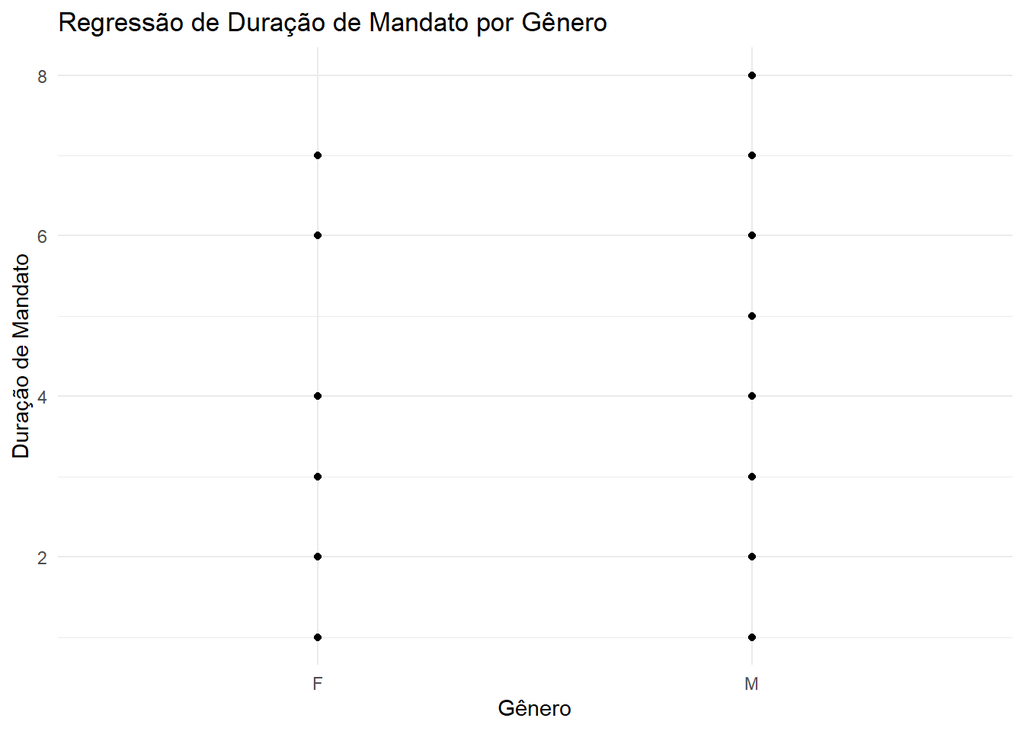

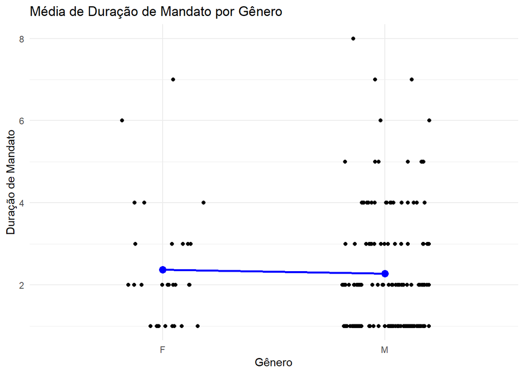

# Limitações

Apesar da regressão linear ser a mais utilizada e recomendada para testar correlações entre variáveis, nem sempre ela é a ideal sem os devidos ajustes. No caso apresentado, o mais adequado seria ter outras variáveis, ou uma possível variável de controle e que fosse realizada uma regressão linear múltipla. Por isso, nossos resultados apresentam limitações e a utilização não adequadra do método estatítico também.